# Description of analysis steps

Mumtahena Rahman

January 29, 2015

## Analysis of data in the manuscript:

- Manually download the GFP and HER2 overexpressed in human mammary epithelial cells RNA-Seq data from GEO (Accession#GSE62820)
- Manually download the HER2 predictions using RSEM-log2, Rsubread-FPKM-log2 and Rsubread-TPM-log2 TCGA data submitted with manuscript

### Install and load the required package for analysis

### Comparing gene counts

Comparing gene counts results using GFP control protein and ERBB2 protein overexpressed human mammary epithelial cell samples. TCGA’s pipeline and Subread pipelines were used to generate raw gene level counts. Log based 2 gene counts are used to differentiate between control and ERBB2 overexpressed samples.

First, read in the raw counts for GFP and HER2 HMEC samples processed via TCGA pipeline (expected counts) and Rsubread pipeline (integer based), extract the values for ’ERBB2’gene

```
## [1] 1.70127
```

```
## [1] 0.1374262
```

```
## [1] 0.5288109
```

```
## [1] 1.529863
```

```
## [1] 0.182423
```

```
## [1] 0.1469874
```

Then we calculated standardized mean differences and t-test for the gene counts from two pipelines.

```r
merge_drop<-function(x,y,by=0)
{
  new_m<-merge(x,y,by=by)
  rownames(new_m)<-new_m$Row.names
  return(new_m[,2:length(colnames(new_m))])
}
###########here we are computing standardized mean difference using the exprected gene counts from TCGA pipeline and gene counts from Rsubread algorithm ############
standardized_mean<-function(m.1,sd.1,n.1,m.2,sd.2,n.2){
  sd_pooled=sqrt(((n.1-1)*sd.1^2+(n.2-1)*sd.2^2)/(n.1+n.2-2))
  (m.1-m.2)/sd_pooled
  }

####Hedge's standardized mean/effect size using TCGA pipeline
standardized_mean(mean(log2(rsem_her2$TCGA_ERBB2[13:17]+1)),sd(log2(rsem_her2$TCGA_ERBB2[13:17]+1)),5,mean(log2(rsem_her2$TCGA_ERBB2[1:12]+1)),sd(log2(rsem_her2$TCGA_ERBB2[1:12]+1)),12)
```

```
## [1] 10.02632
```

```r
#compute_dgs(n.1 = 5,m.1 = mean(log2(rsem_her2$TCGA_ERBB2[13:17]+1)),sd.1 = sd(log2(rsem_her2$TCGA_ERBB2[13:17]+1)),n.2 =12, m.2 =  mean(log2(rsem_her2$TCGA_ERBB2[1:12]+1)),sd.2 = sd(log2(rsem_her2$TCGA_ERBB2[1:12]+1)),data=rsem_her2)#standardized difference is denoted by d.and it is 3.573901 for rsubread processed data

####Hedge's standardized mean/effect size using Rsubread pipeline
standardized_mean(m.1=mean((log2(rsub_her2$Rsubread_ERBB2[13:17]+1))),sd.1=sd((log2(rsub_her2$Rsubread_ERBB2[13:17]+1))),n.1=5,m.2=mean((log2(rsub_her2$Rsubread_ERBB2[1:12]+1))),sd.2=sd((log2(rsub_her2$Rsubread_ERBB2[1:12]+1))),n.2 = 12)
```

```
## [1] 23.75383
```

```r
compute_dgs(n.1 = 5,m.1 = mean((log2(rsub_her2$Rsubread_ERBB2[13:17]+1))),sd.1 = sd((log2(rsub_her2$Rsubread_ERBB2[13:17]+1))),n.2 =12, m.2 =  mean((log2(rsub_her2$Rsubread_ERBB2[1:12]+1))),sd.2 = sd((log2(rsub_her2$Rsubread_ERBB2[1:12]+1))),data=rsub_her2)
```

```
##        Rsubread_ERBB2  s.within        d    var.d      g    var.g     se.g
## GFP-1            2953 0.2496644 23.75383 16.87875 22.546 15.20591 3.899476
## GFP-2            2599 0.2496644 23.75383 16.87875 22.546 15.20591 3.899476
## GFP-3            2705 0.2496644 23.75383 16.87875 22.546 15.20591 3.899476
## GFP-4            3042 0.2496644 23.75383 16.87875 22.546 15.20591 3.899476
## GFP-5            3578 0.2496644 23.75383 16.87875 22.546 15.20591 3.899476
## GFP-6            2358 0.2496644 23.75383 16.87875 22.546 15.20591 3.899476
## GFP-7            2988 0.2496644 23.75383 16.87875 22.546 15.20591 3.899476
## GFP-8            2705 0.2496644 23.75383 16.87875 22.546 15.20591 3.899476
## GFP-9            3253 0.2496644 23.75383 16.87875 22.546 15.20591 3.899476
## GFP-10           2935 0.2496644 23.75383 16.87875 22.546 15.20591 3.899476
## GFP-11           4147 0.2496644 23.75383 16.87875 22.546 15.20591 3.899476
## GFP-12           2136 0.2496644 23.75383 16.87875 22.546 15.20591 3.899476
## HER2-1         187197 0.2496644 23.75383 16.87875 22.546 15.20591 3.899476
## HER2-2         204253 0.2496644 23.75383 16.87875 22.546 15.20591 3.899476
## HER2-3         179082 0.2496644 23.75383 16.87875 22.546 15.20591 3.899476
## HER2-5         189998 0.2496644 23.75383 16.87875 22.546 15.20591 3.899476
## HER2-6         134889 0.2496644 23.75383 16.87875 22.546 15.20591 3.899476
```

Boxplot of ERBB2 gene counts from TCGA and Rsubread pipeline right after read alignment

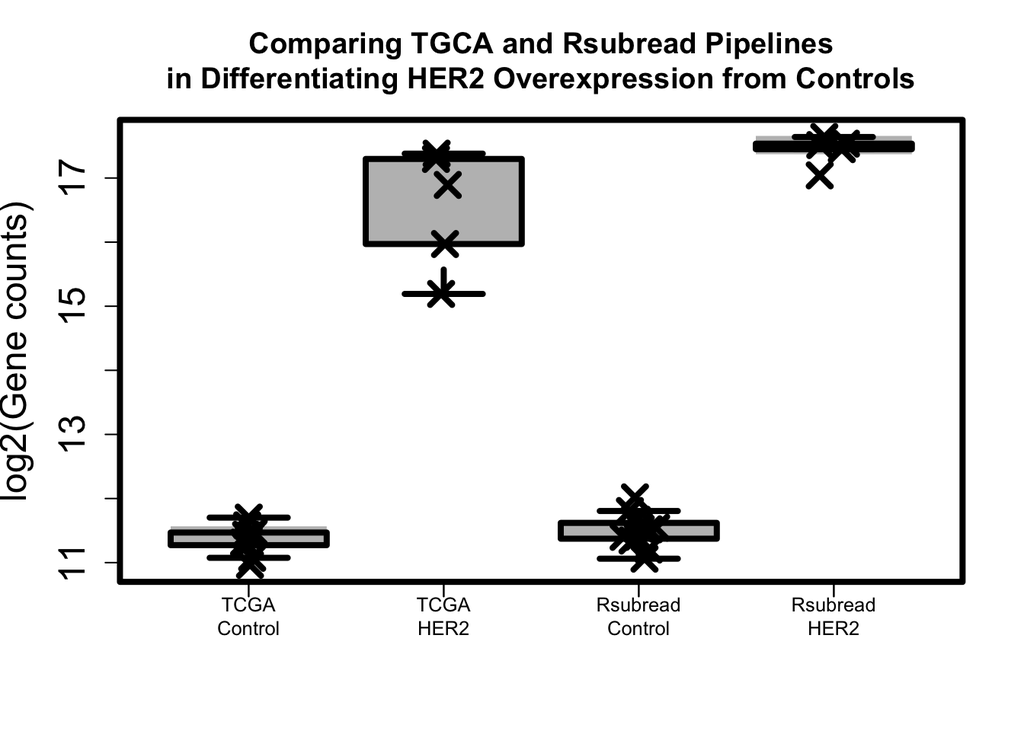

```r
#######Boxplotting ERBB2 gene counts in HMEC samples#####
par(mfrow = c(1, 1),lwd=4)
names=c('TCGA\nGFP','TCGA\nHER2','Rsubread\nGFP', 'Rsubread\nHER2')

x = c(rep(1, 12), rep(2, 5),rep(3, 12), rep(4, 5))
#plot(jitter(x,factor=1.5),jitter(c(log2(rsem_her2$TCGA_ERBB2[1:12]+1),log2(rsem_her2$TCGA_ERBB2[13:17]+1),log2(rsub_her2$Rsubread_ERBB2[1:12]+1),log2(rsub_her2$Rsubread_ERBB2[13:17]+1)),factor=1.5), pch=20, cex=2,add=T,col=(x+1%%2)+1,xlab="",ylab="")
boxplot(log2(rsem_her2$TCGA_ERBB2[1:12]+1),log2(rsem_her2$TCGA_ERBB2[13:17]+1),log2(rsub_her2$Rsubread_ERBB2[1:12]+1),log2(rsub_her2$Rsubread_ERBB2[13:17]+1),xlab='',ylab="log2(Gene counts)",main=paste('Comparing TGCA and Rsubread Pipelines','\n', 'in Differentiating HER2 Overexpression from Controls',sep=''),cex.axis=1.5, cex.lab=1.5,outpch=NA,col='grey',medcol="grey",lwd=4)
points(jitter(rep(1,12),factor=1.5),log2(rsem_her2$TCGA_ERBB2[1:12]+1),pch=4,cex=2,cex.lab=1.5,col="black")
points(jitter(rep(2,5),factor=1.5),log2(rsem_her2$TCGA_ERBB2[13:17]+1),pch=4,cex=2,cex.lab=1.5,col='black')
points(jitter(rep(3,12),factor=1.5),log2(rsub_her2$Rsubread_ERBB2[1:12]+1),pch=4,cex=2,cex.lab=1.5,col='black')
points(jitter(rep(4,5),factor=1.5),log2(rsub_her2$Rsubread_ERBB2[13:17]+1),pch=4,cex=2,cex.lab=1.5,col='black')


#text(seq(1,6,by=1),par("usr")[3] - 1, labels = names, srt = 45, pos = 1, xpd = TRUE)
axis(1, at=1:4, tick=T, labels=c("TCGA\nControl", "TCGA\nHER2","Rsubread\nControl", "Rsubread\nHER2"), cex.axis=0.8)
```

```r
##using data processed by RSEM detected difference in her2 gene count in HER2 overexpressed versus GFP overexpressed samples
##t = -12.1833, df = 4.157, p-value = 0.0002081 but was worse than Rsubread

t.test(log2(rsem_her2$TCGA_ERBB2[1:12]+1),log2(rsem_her2$TCGA_ERBB2[13:17]+1))
```

```
##
##  Welch Two Sample t-test
##
## data:  log2(rsem_her2$TCGA_ERBB2[1:12] + 1) and log2(rsem_her2$TCGA_ERBB2[13:17] + 1)
## t = -12.1823, df = 4.157, p-value = 0.0002082
## alternative hypothesis: true difference in means is not equal to 0
## 95 percent confidence interval:
##  -6.342716 -4.016535
## sample estimates:
## mean of x mean of y
##  11.36677  16.54640
```

```r
##using not normalized data processed by Rsubread was much better at detecting difference in her2 gene count in HER2 overexpressed versus GFP overexpressed samples
##t = -46.6747, df = 8.35, p-value = 2.152e-11
t.test(log2(rsub_her2$Rsubread_ERBB2[1:12]+1),log2(rsub_her2$Rsubread_ERBB2[13:17]+1))
```

```
##
##  Welch Two Sample t-test
##
## data:  log2(rsub_her2$Rsubread_ERBB2[1:12] + 1) and log2(rsub_her2$Rsubread_ERBB2[13:17] + 1)
## t = -46.6763, df = 8.348, p-value = 2.165e-11
## alternative hypothesis: true difference in means is not equal to 0
## 95 percent confidence interval:
##  -6.221365 -5.639603
## sample estimates:
## mean of x mean of y
##  11.50582  17.43631
```

Both methods find significant differences in the ERBB2 read counts between GFP control and HER2 samples. However, coefficient of variable is less with Rsubread data than TCGA pipeline processed data. Moreover, standardized mean differences in ERBB2 gene counts between HER2 activated and control samples using TCGA pipeline is smaller than the Rsubread pipeline processed data.

```r
############computing total number of read counts per samples and plotting them as dot plots####
expected_counts<-apply(rsem_her2_expected_counts,2,sum)
feature_counts<-apply(feature,2,sum)
# Creating a plot showing total mapped reads per sample
#pdf("~/Dropbox/Bioinformatics submission/Resubmission/updated figures/Total_mapped_reads_dot_plot.pdf",  pointsize = 8)
pdf("~/Dropbox/Bioinformatics submission/Resubmission/updated figures/all_figures.pdf",  pointsize = 8)
par( mfrow = c( 1, 2 ),lwd=4 )
x = c(rep(1, 12), rep(2, 5)) # this indicates where on the x axis to plot
par(mar=c(3.1, 4.6, 2.1, 0.6)) # figure margins
boxplot(log2(expected_counts[1:12]+1), log2(expected_counts[13:17]+1),range=0,cex.axis=1.5, cex.lab=1.5,outpch=NA,col='grey',medcol="grey",lwd=3,ylim=c(20,25),xlab="", ylab="log2(Total mapped reads)",main="TCGA Level 3",lwd=4)
points(jitter(x, factor=1.5), c(log2(expected_counts[1:12]+1), log2(expected_counts[13:17]+1)), pch=20, cex=2.5, col=x+1,  xaxt="n", cex.axis=1.5, cex.lab=1.5)
axis(1, at=1:2, tick=T, labels=c("Control", "HER2"), cex.axis=1.5) # this gives us more control over the axis

boxplot(log2(feature_counts[1:12]+1), log2(feature_counts[13:17]+1),range=0,cex.axis=1.5, cex.lab=1.5,outpch=NA,col='grey',medcol="grey",lwd=3,ylim=c(20,25),xlab="", ylab="log2(Total mapped reads)")
points(jitter(x, factor=1.5), c(log2(feature_counts[1:12]+1), log2(feature_counts[13:17]+1)), pch=20, cex=2.5, col=x+1, ylim=c(23,25),xaxt="n", cex.axis=1.5, cex.lab=1.5, main="Rsubread")
axis(1, at=1:2, tick=T, labels=c("Control", "HER2"), cex.axis=1.5) # this gives us more control over the axis
#dev.off()

##########computing the empiric cumulative distribution per sample overlaied on same graph########
#pdf("~/Dropbox/Bioinformatics submission/Resubmission/updated figures/ecdfs_all_genes.pdf",  pointsize = 8)
###using TCGA pipelined aligned data
ecdf_all_ex<-apply(log2(rsem_her2_expected_counts+1),2,ecdf)
par( mfrow = c( 1, 2 ) )
plot(ecdf_all_ex[[1]],xlab=NA, ylab = NA,col="blue",main="TCGA pipeline",ylim=c(0,1),xlim = c(0,20),cex.axis=1.5, cex.lab=1.5,legend.text = c("HER2 samples","GFP samples"))
legend(10,10,c("GFP", "HER2"), col = c("blue","brown"))
for(i in 2:12){lines(ecdf_all_ex[[i]],xlab=NA, ylab = NA,col="blue")}
for(i in 13:17){lines(ecdf_all_ex[[i]],xlab=NA, ylab = NA,col="brown")}
###using Rsubread pipeline aligned data
ecdf_all<-apply(log2(feature+1),2,ecdf)
#par(mfrow = c(1,1))
plot(ecdf_all[[1]],xlab=NA, ylab = NA,col="blue",main="Rsubread pipeline",ylim=c(0,1),xlim = c(0,20),cex.axis=1.5, cex.lab=1.5,)
for(i in 2:12){lines(ecdf_all[[i]],xlab=NA,ylab = NA,col="blue")}
for(i in 13:17){lines(ecdf_all[[i]],xlab=NA,ylab = NA,col="brown")}
#dev.off()



# pdf("~/Dropbox/Bioinformatics submission/Resubmission/updated figures/HER2_reads_dot_plot.pdf",  pointsize = 8)
# par( mfrow = c( 1, 1 ) )
# x = c(rep(1, 12), rep(2, 5),rep(3, 12), rep(4, 5)) # this indicates where on the x axis to plot
# par(mar=c(3.1, 4.6, 2.1, 0.6)) # figure margins
# plot(jitter(x,factor=4,amount = 0.1), c(log2(rsem_her2$TCGA_ERBB2[1:12]),log2(rsem_her2$TCGA_ERBB2[13:17]),log2(rsub_her2$Rsubread_ERBB2[1:12]),log2(rsub_her2$Rsubread_ERBB2[13:17])), pch=20, cex=2, col=c(rep(3, 12), rep(2, 5),rep(3, 12), rep(2, 5)),ylim=c(0,20), xlab="", ylab="log2(Gene Count)", xaxt="n", cex.axis=1.5, cex.lab=1.5, main="Comparing HER2 Gene Counts",)
# axis(1, at=1:4, tick=T, labels=c("TCGA\nControl", "TCGA\nHER2","Rsubread\nControl", "Rsubread\nHER2"), cex.axis=0.8) # this gives us more control over the axis
#
# dev.off()
```

### 3.c. Comparing normalized gene counts

Manually download the processed files for this analysis from GEO (Accession#GSE62820)

```
## [1] 1.590576
```

```
## [1] 0.20566
```

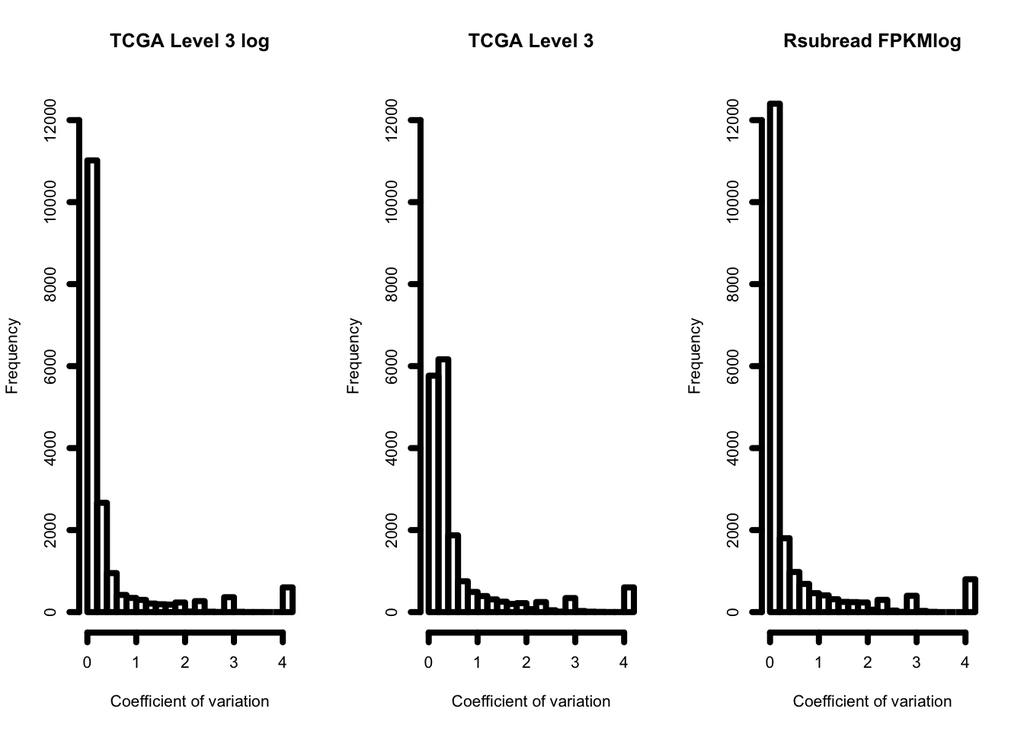

```
## [1] 0.39219
```

```
## [1] 1.501472
```

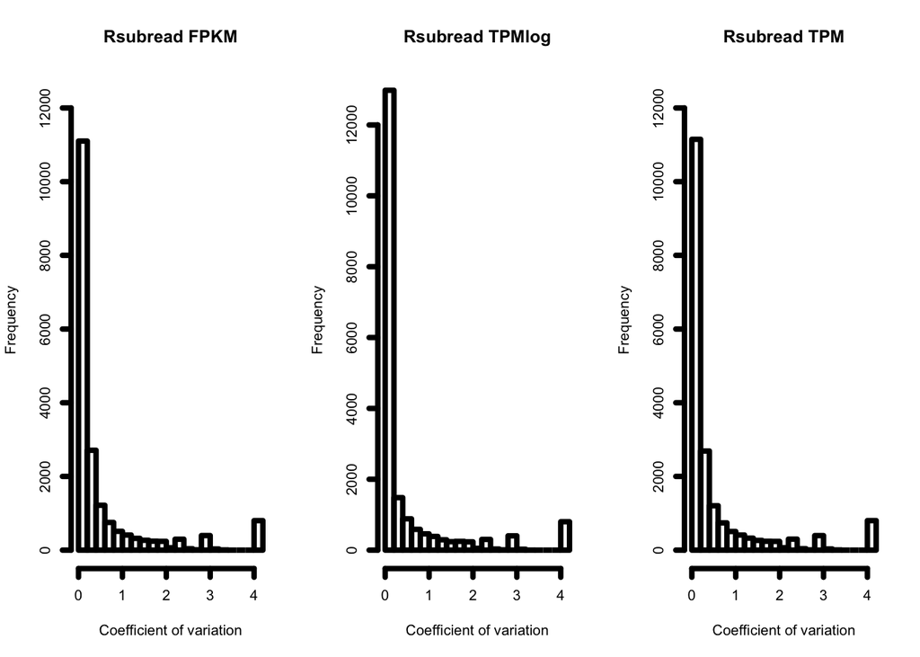

```
## [1] 0.3196422
```

```
## [1] 25.77642
```

```
## [1] 25.77642
```

```
## [1] 66.91743
```

```
## [1] 67.15595
```

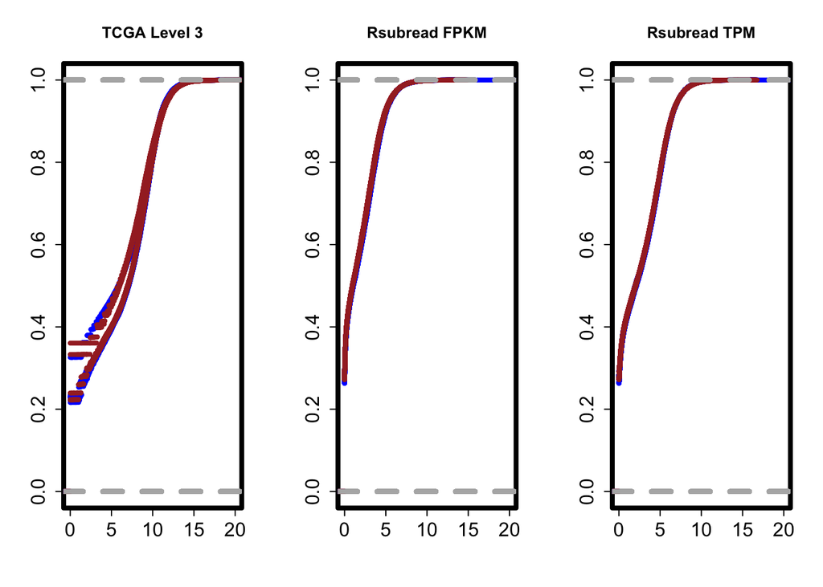

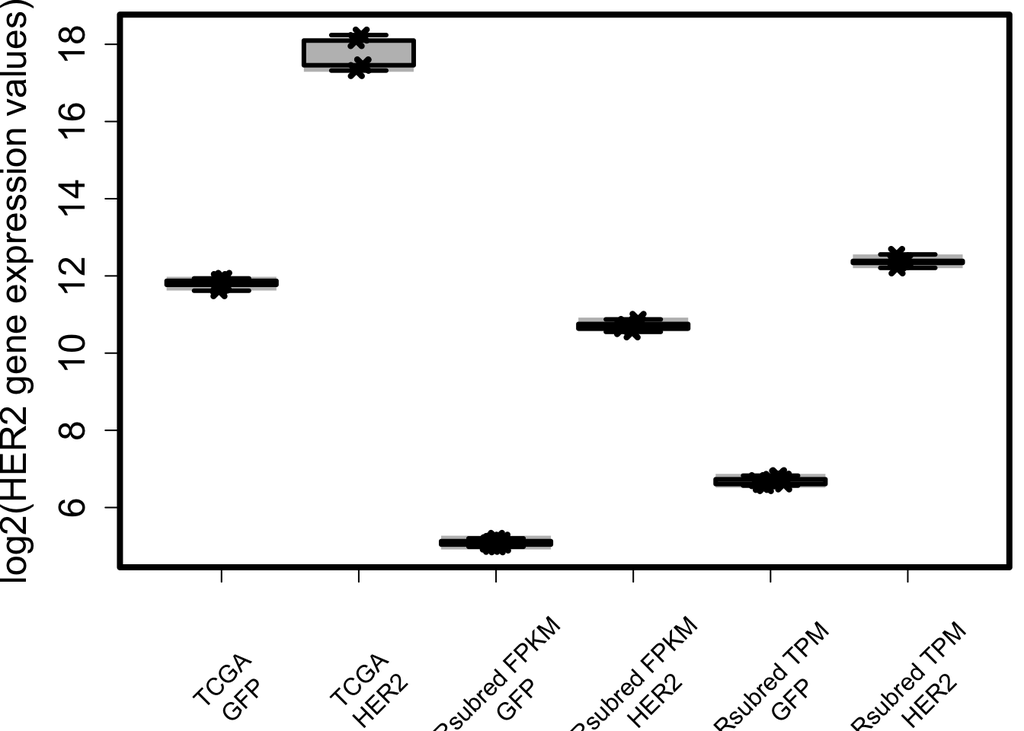

```
##
##  Welch Two Sample t-test
##
## data:  log2(tcga_her2_normalized$ERBB2[1:12] + 1) and log2(tcga_her2_normalized$ERBB2[13:17] + 1)
## t = -31.2088, df = 4.145, p-value = 4.463e-06
## alternative hypothesis: true difference in means is not equal to 0
## 95 percent confidence interval:
##  -6.430039 -5.392647
## sample estimates:
## mean of x mean of y
##  11.80428  17.71562
```

```
##
##  Welch Two Sample t-test
##
## data:  rsub_fpkmlog_her2$Rsubread_FPKMlog_ERBB2[1:12] and rsub_fpkmlog_her2$Rsubread_FPKMlog_ERBB2[13:17]
## t = -96.8806, df = 4.939, p-value = 2.73e-09
## alternative hypothesis: true difference in means is not equal to 0
## 95 percent confidence interval:
##  -5.775412 -5.475761
## sample estimates:
## mean of x mean of y
##  5.085548 10.711135
```

```
##
##  Welch Two Sample t-test
##
## data:  rsub_tpmlog_her2$Rsubread_TPMlog_ERBB2[1:12] and rsub_tpmlog_her2$Rsubread_TPMlog_ERBB2[13:17]
## t = -93.9768, df = 5.501, p-value = 4.949e-10
## alternative hypothesis: true difference in means is not equal to 0
## 95 percent confidence interval:
##  -5.837449 -5.534713
## sample estimates:
## mean of x mean of y
##  6.687464 12.373545
```

### Comparing Her2 Predictions

We predicted HER2 pathway using our overexpressed samples in human mammary epithelial cells(HMECs) in TCGA breast cancer samples. We used TCGA pipeline processed HMEC datasets on TCGA pipeline processed TCGA BRCA samples and Rsubread pipelined processed HMEC datasets on Rsubread processed TCGA BRCA samples. We only compared BRCA samples that are common and we have her2 status confirmed by immunohistochemistry. Our goal here is to compare how well these two pipeline and normalization method differenciate HER2 pathway activity predictions where we know the status of HER2 overexpression.

We removed all the genes that had zero expression accross all HMEC samples and TCGA samples. Then, we used quantile normalization method to adjust for batch variation between our HMEC training samples and TCGA BRCA samples. We used binary regression model developed by West et al to generate HER2 signatures using top 200 genes. The signature generated from each pipeline processed data was used to predict on TCGA BRCA RNA-Seq sample processed by the same pipeline. Both FPKM-log2 and TPM-log2 normalized Rsubread processed predictions were compiled to one file and TCGA upper-quantile log-2 normalized pipeline procssed predictions were extracted to another file for analysis.

```r
#############Reading in predicted HER2 pathway activity#############################################
setwd("~/Dropbox/TCGA_PANCAN20_manuscript/Datasets/Analysis datasets/")
rsub_preds<-read.table("rsubread_10_14.txt", sep='\t', header=1, row.names=1)
tcga_preds<-read.table("Rsem_10_14.txt", sep='\t', header=1, row.names=1)
all_preds<-merge(rsub_preds,tcga_preds,by=0)
rownames(all_preds)<-all_preds$Row.names
all_preds<-subset(all_preds,select=-Row.names)
clinicals<-t(read.delim('TCGA20_clinical_data_ordered_all_clinical_variables_samples_as_columns.txt',sep='\t',header=1, row.names=1,check.names=F))
brca_clinical<-subset(clinicals,clinicals[,'tumor_tissue_site']=='Breast',select=c("bcr_patient_barcode","her2_status_by_ihc"))
common_all<-merge(all_preds,brca_clinical,by=0)
rownames(common_all)<-common_all$Row.names
common_all<-subset(common_all,select=-Row.names)
all_preds_pos_neg<-subset(common_all,common_all$her2_status_by_ihc=="Negative"|common_all$her2_status_by_ihc=="Positive")

all_ranked<-apply(all_preds_pos_neg[,1:3],2,rank)
all<-cbind(all_ranked,all_preds_pos_neg[,4:5])
ihc_neg<-subset(all,all$her2_status_by_ihc=="Negative")
ihc_pos<-subset(all,all$her2_status_by_ihc=="Positive")
```

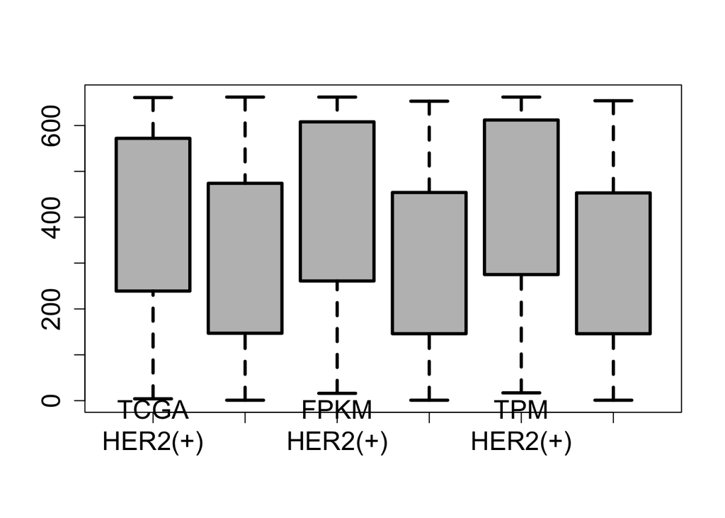

```r
##############boxplot of ranked estimated HER2 pathway activity
##in TCGA BRCA samples####
#pdf("~/Dropbox/Bioinformatics submission/Resubmission/updated figures/HER2_prediction_box_plot.pdf",  pointsize = 8)
par(mfrow = c(1, 1))
boxplot(ihc_pos$Rsem_log_q_200_f,ihc_neg$Rsem_log_q_200_f,ihc_pos$FPKM_log_q_200_f,ihc_neg$FPKM_log_q_200_f,ihc_pos$TPM_log_q_200_f,ihc_neg$TPM_log_q_200_f,cex.axis=1.5, cex.lab=1.5,outpch=NA,col='grey',medcol="grey",lwd=3,names=c("TCGA\nHER2(+)","TCGA\nHER2(-)","FPKM\nHER2(+)","FPKM\nHER2(-)","TPM\nHER2(+)","TPM\nHER2(-)"),range=0)
```

```r
#dev.off()

##Now, doing a t-test for comparing the Her2(+) and Her2(-) BRCA samples and measuring coefficient of variations for the predictions

## t-tests comparing HER(+) and HER(-) prediction
ihc_neg_t<-subset(common_all,common_all$her2_status_by_ihc=="Negative")
ihc_pos_t<-subset(common_all,common_all$her2_status_by_ihc=="Positive")

standardized_mean(m.1=mean(ihc_pos_t$Rsem_log_q_200_f),sd.1=sd(ihc_pos_t$Rsem_log_q_200_f),n.1=length(ihc_pos_t$Rsem_log_q_200_f),m.2=mean(ihc_neg_t$Rsem_log_q_200_f),sd.2=sd(ihc_neg_t$Rsem_log_q_200_f),n.2=length(ihc_neg_t$Rsem_log_q_200_f))
```

```
## [1] 0.4378996
```

```r
standardized_mean(m.1=mean(ihc_pos_t$FPKM_log_q_200_f),sd.1=sd(ihc_pos_t$FPKM_log_q_200_f),n.1=length(ihc_pos_t$FPKM_log_q_200_f),m.2=mean(ihc_neg_t$FPKM_log_q_200_f),sd.2=sd(ihc_neg_t$FPKM_log_q_200_f),n.2=length(ihc_neg_t$FPKM_log_q_200_f))
```

```
## [1] 0.5176175
```

```r
standardized_mean(m.1=mean(ihc_pos_t$TPM_log_q_200_f),sd.1=sd(ihc_pos_t$TPM_log_q_200_f),n.1=length(ihc_pos_t$TPM_log_q_200_f),m.2=mean(ihc_neg_t$TPM_log_q_200_f),sd.2=sd(ihc_neg_t$TPM_log_q_200_f),n.2=length(ihc_neg_t$TPM_log_q_200_f))
```

```
## [1] 0.5901463
```

```r
t.test(ihc_pos_t$Rsem_log_q_200_f,ihc_neg_t$Rsem_log_q_200_f)#p-value = 2.009e-05
```

```
##
##  Welch Two Sample t-test
##
## data:  ihc_pos_t$Rsem_log_q_200_f and ihc_neg_t$Rsem_log_q_200_f
## t = 4.3599, df = 217.213, p-value = 2.009e-05
## alternative hypothesis: true difference in means is not equal to 0
## 95 percent confidence interval:
##  0.05731397 0.15188620
## sample estimates:
## mean of x mean of y
## 0.4256819 0.3210818
```

```r
t.test(ihc_pos_t$FPKM_log_q_200_f,ihc_neg_t$FPKM_log_q_200_f)#p-value = 1.493e-10
```

```
##
##  Welch Two Sample t-test
##
## data:  ihc_pos_t$FPKM_log_q_200_f and ihc_neg_t$FPKM_log_q_200_f
## t = 6.6169, df = 328.368, p-value = 1.493e-10
## alternative hypothesis: true difference in means is not equal to 0
## 95 percent confidence interval:
##  0.05522649 0.10195772
## sample estimates:
## mean of x mean of y
## 0.8529022 0.7743100
```

```r
t.test(ihc_pos_t$TPM_log_q_200_f,ihc_neg_t$TPM_log_q_200_f)#p-value = 3.197e-12
```

```
##
##  Welch Two Sample t-test
##
## data:  ihc_pos_t$TPM_log_q_200_f and ihc_neg_t$TPM_log_q_200_f
## t = 7.2634, df = 303.609, p-value = 3.197e-12
## alternative hypothesis: true difference in means is not equal to 0
## 95 percent confidence interval:
##  0.08497343 0.14812503
## sample estimates:
## mean of x mean of y
## 0.8086601 0.6921109
```

Both pipelines were significant in differentiating between HER2(+) and HER(-) samples using our HER2 signature. However, Rsubread has the bigger difference between the two subtypes shown as standardized mean.

Now, checking the consistency of the prediction using coefficient of variation analysis TCGA’s pipeline produced predictions that has higher coeffecient of variation 0.6860363 compared to Rsubread’s coefficient of variation, 0.2021242 for FPKM data and 0.2898588 for TPM data.

Now checking the total number of zeros per samples in the common samples accross PanCan12 and our datasets

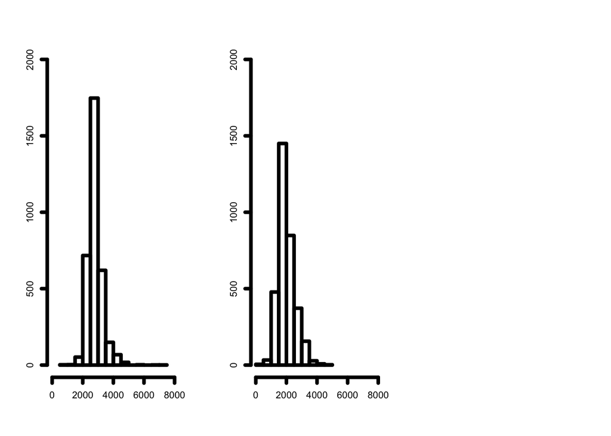

```r
pancan12_zero<-read.table("~/Desktop/PANCAN12_19583_by_3380_numZeroes.txt",row.names=1,sep='\t',skip = 1)
colnames(pancan12_zero)<-"PANCAN12"
#pancan20_fpkm_zero<-read.table("~/Desktop/PANCAN20_19583_by_3380_numZeroes.txt",row.names=1,sep='\t',skip = 1)
#colnames(pancan20_fpkm_zero)<-"FPKM"
pancan20_tpm_zero<-read.table("~/Desktop/PANCAN20_19583_by_3380_numZeroes.txt",sep='\t',row.names=1,skip = 1)
colnames(pancan20_tpm_zero)<-"TPM"
#fpkm_tpm<-merge_drop(pancan20_fpkm_zero,pancan20_tpm_zero,by=0)
all_zeros<-merge_drop(pancan12_zero,pancan20_tpm_zero)
#3380 samples are common
par(mfrow = c(1, 3),lwd=4)
h1<-hist(all_zeros$PANCAN12,xlab='',ylab='',main='',xlim=c(0,8000),ylim=c(0,2000),lwd=4)
#h2<-hist(all_zeros$FPKM,xlab='',ylab='',main='',xlim=c(0,8000),ylim=c(0,2000),lwd=4)
h3<-hist(all_zeros$TPM,xlab='',ylab='',main='',xlim=c(0,8000),ylim=c(0,2000),lwd=4)
```

This analysis was run on Tue Feb 24 08:49:38 2015